# 第13回 強化学習の店長を、本当に入れてよいか

経済プログラミング特論II

第13回・開店 54 日目

強化学習の店長を、  
本当に入れてよいか

比べる相手と天井を、先に決める

経済プログラミング特論II

第13回・開店 54 日目 — Topic01

強化学習の全体像

前の学び方と、その別バージョン

## うちの店でしてきたこと

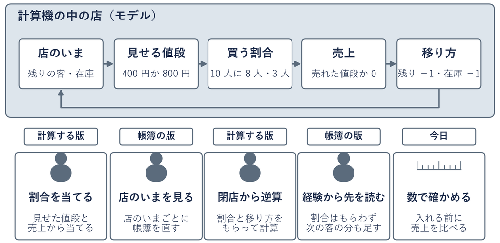

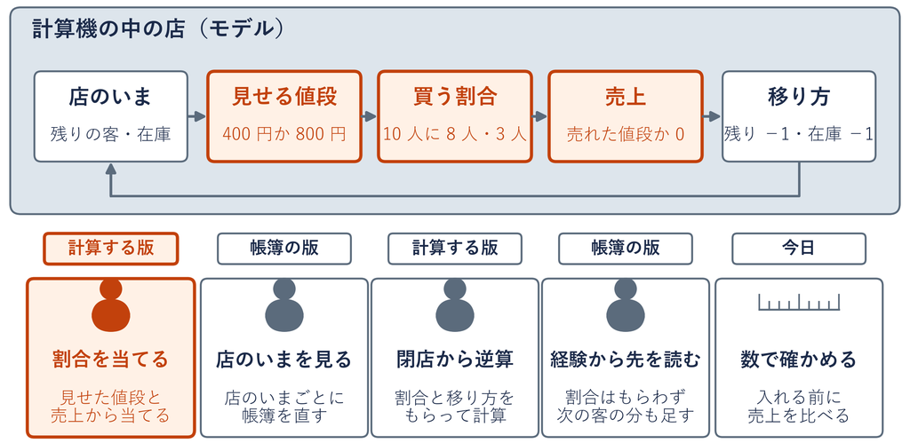

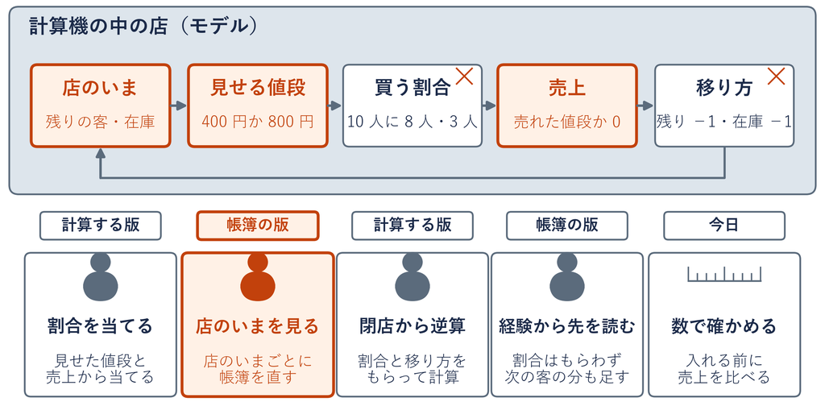

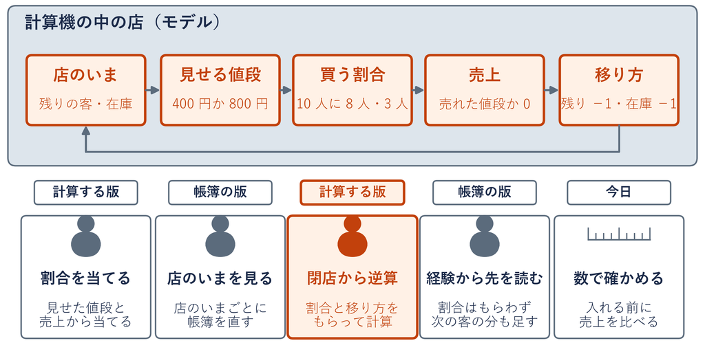

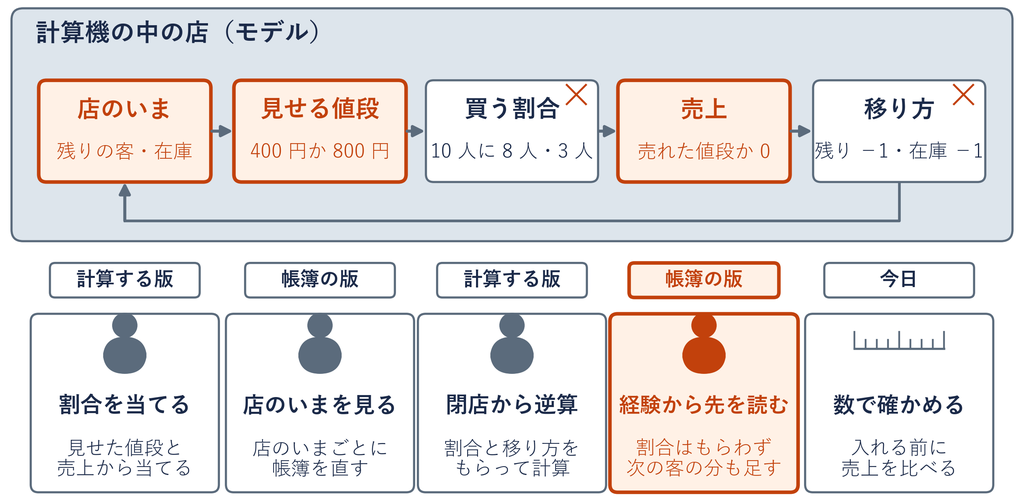

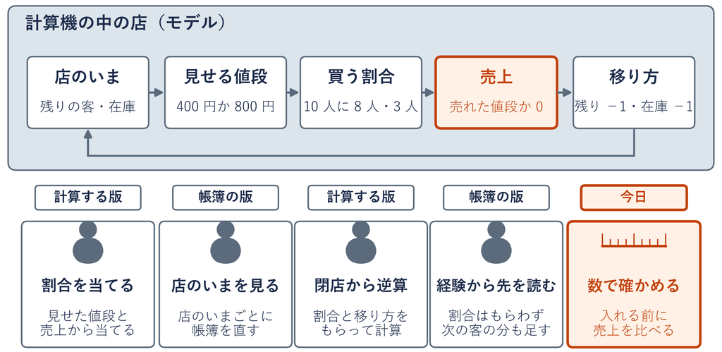

## 今日の道のり

1

強化学習の全体像

動画で振り返る

2

入れる前に確かめる

実習：写経 日数のループ

演習 1 1000 日を足して、測り方を選ぶ

## 強化学習の輪

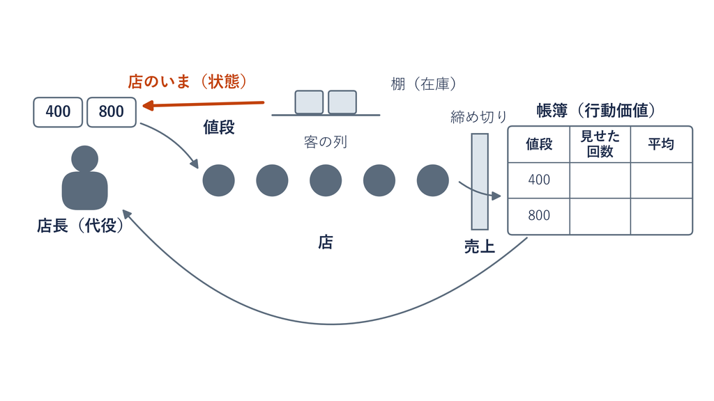

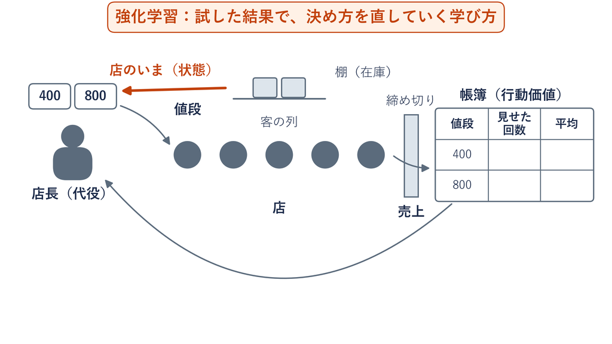

## 同じ輪と 1 か所の差し替え

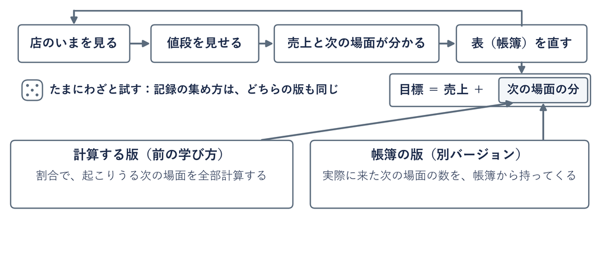

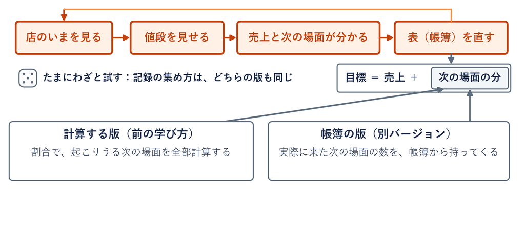

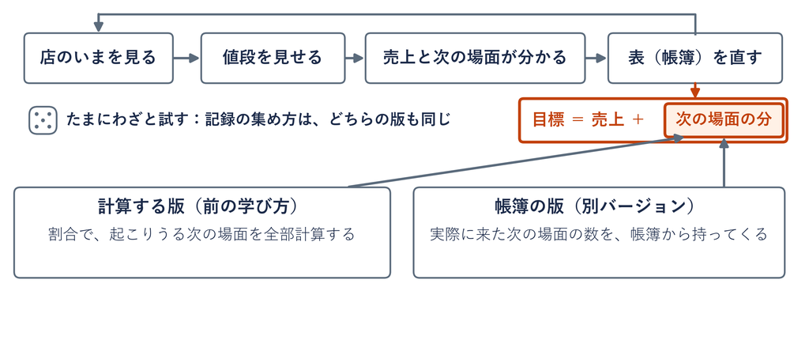

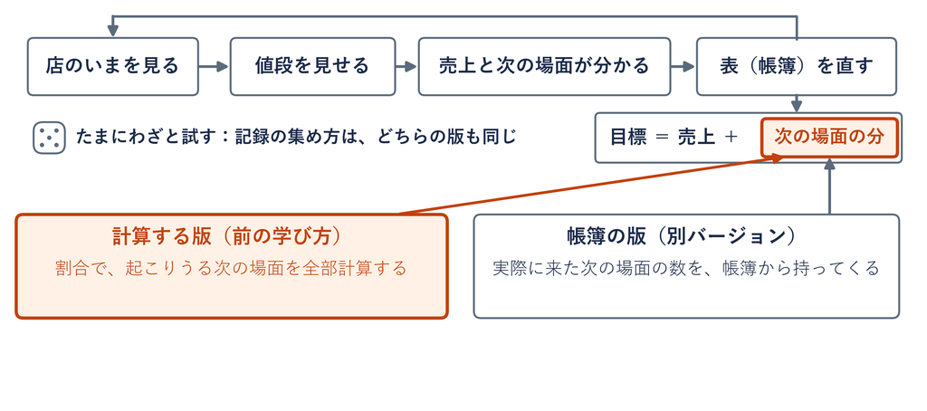

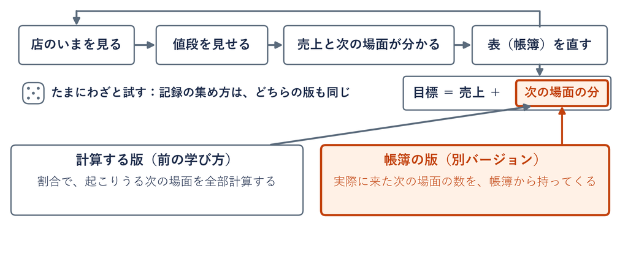

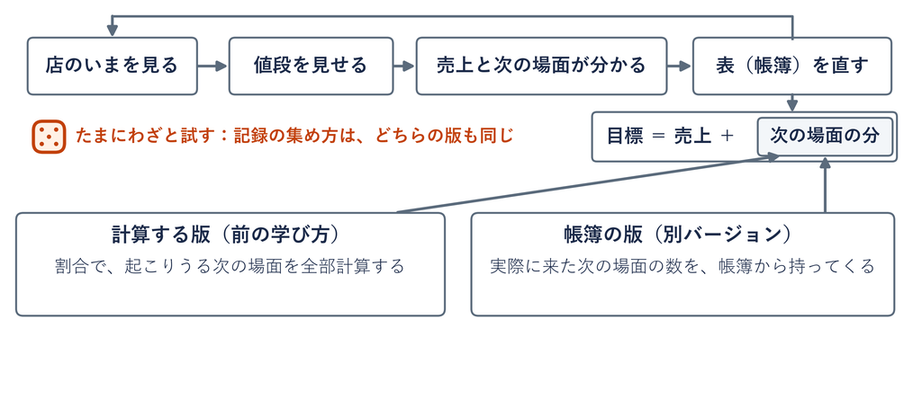

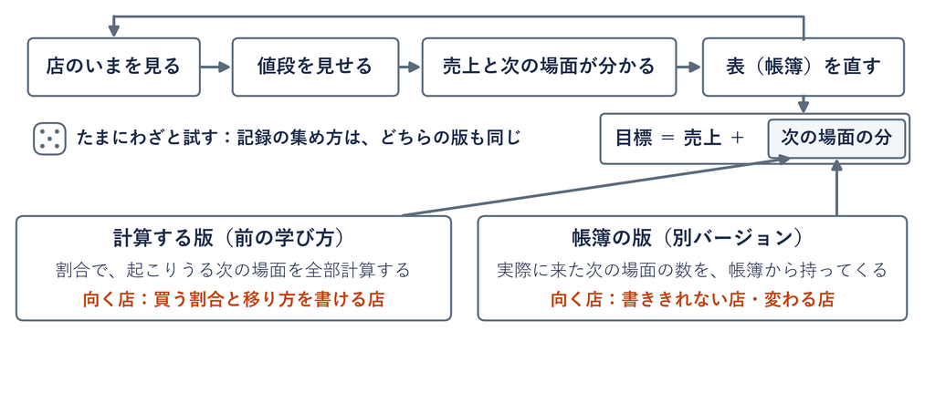

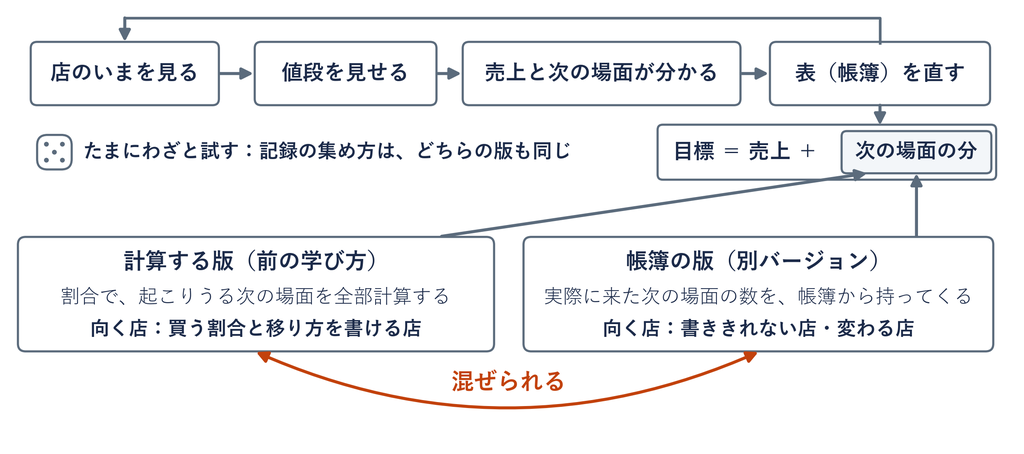

客 1 人に値段を見せるだけの店では、どちらの版も同じ数（帳簿の数 → 当てた割合 × 値段）  
分かれるのは、売れると在庫が減って、見せる値段が変わる店から

どちらの版も同じ店（店のいま・見せる値段・売上・移り方）を解く  
違うのは 1 か所：次の場面の分を、割合で計算するか、帳簿から持ってくるか

## 部品：帳簿

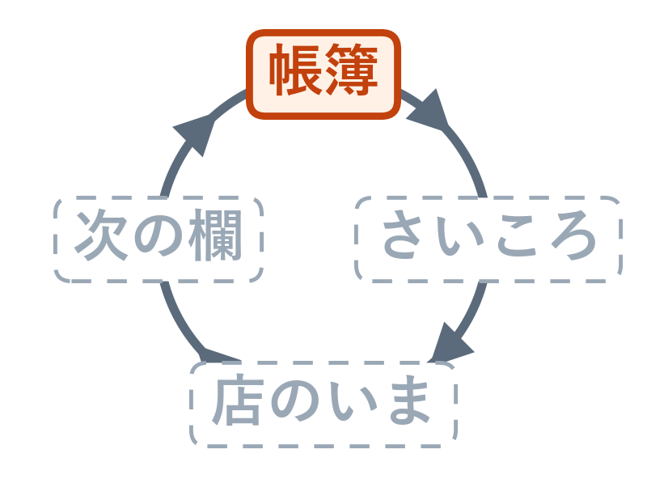

帳簿の版：試した結果を貯める

売上 400, 400, 400, 0, 400 の 5 件 → 平均は 1600 ÷ 5 ＝ **320 円**

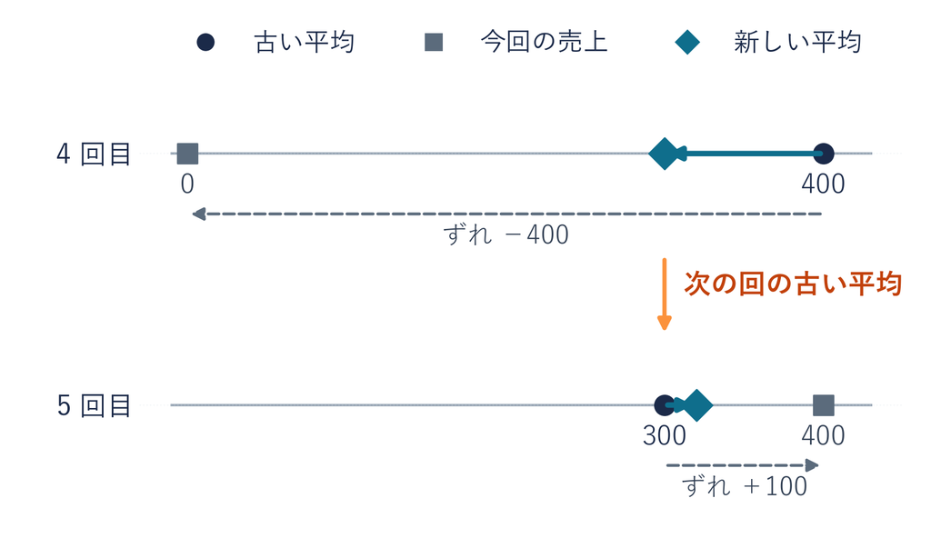

帳簿の数＝試して貯めた数（売れなかった 0 も入れる）

## 部品：さいころ

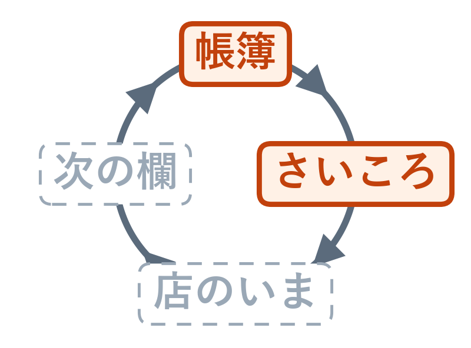

どちらの版も：さいころ

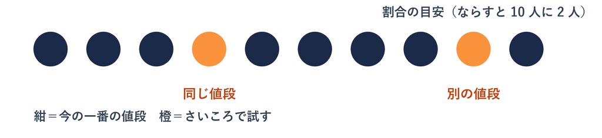

試すのは 5 人に 1 人（10 人に 2 人）、今の一番と別の値段になるのは 10 人に 1 人

**ふだんは一番、たまにわざと**

## 部品：店のいまと値段の表

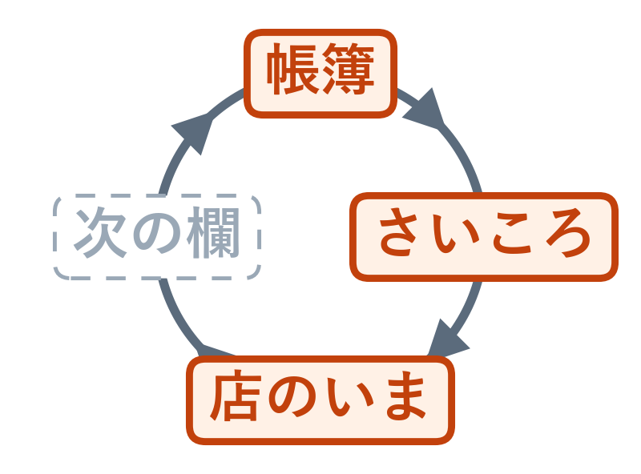

計算する版：当てた割合で作った表

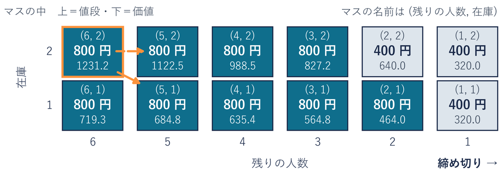

左＝開店（残り 6 人）・右＝締め切り（残り 1 人）  
方策、つまり状態ごとの値段の決め方

## 部品：次の欄

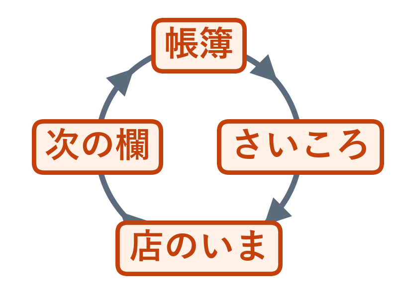

帳簿の版：次の欄を足して直す

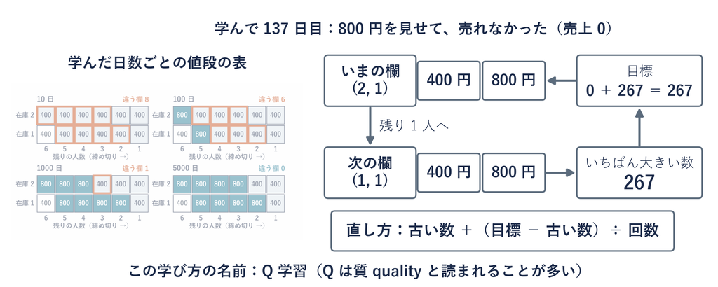

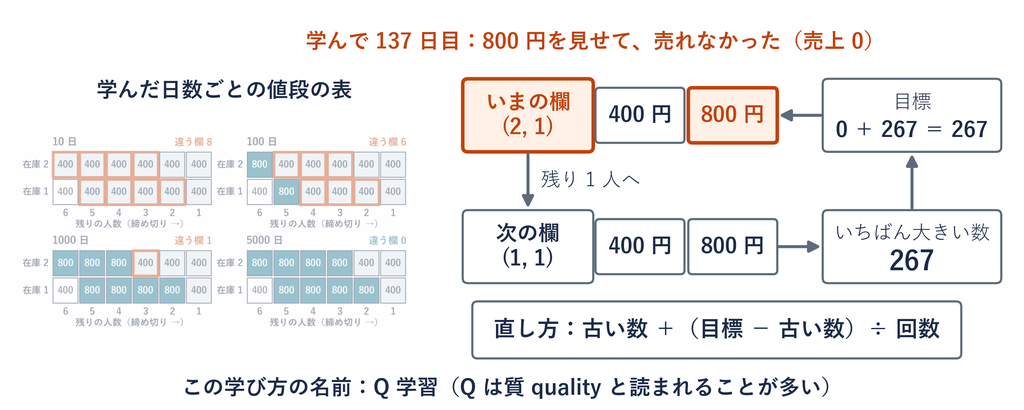

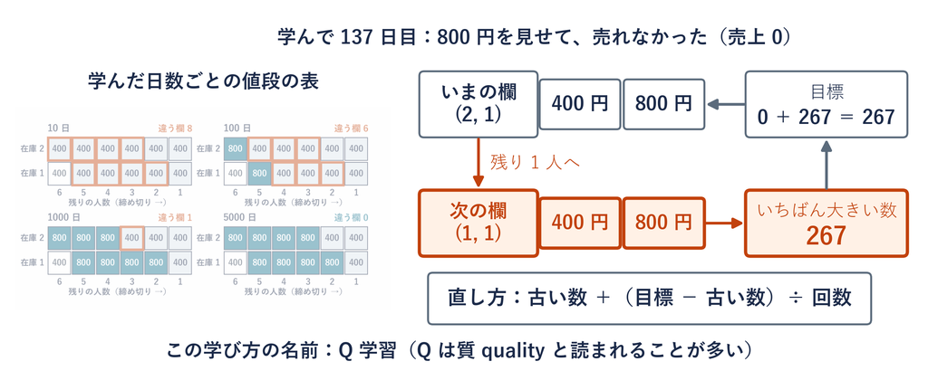

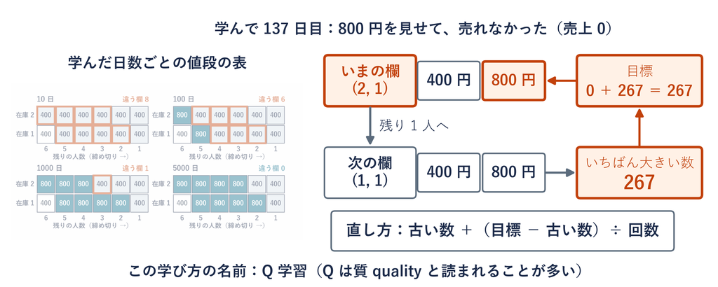

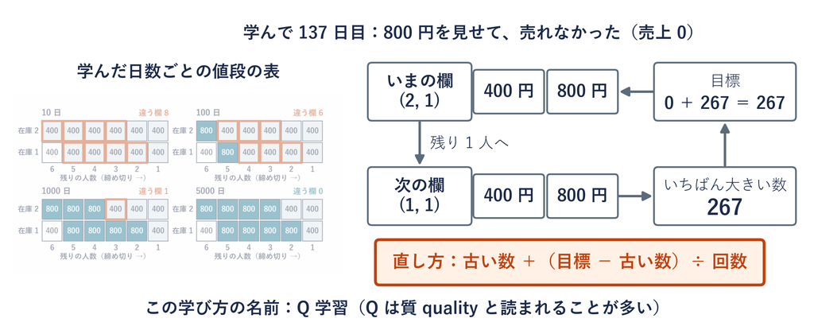

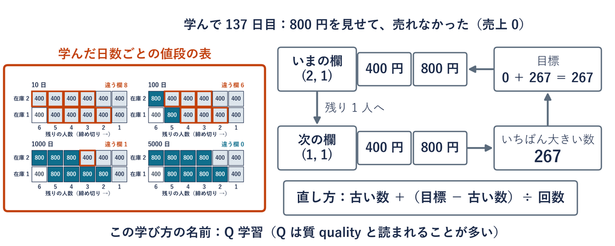

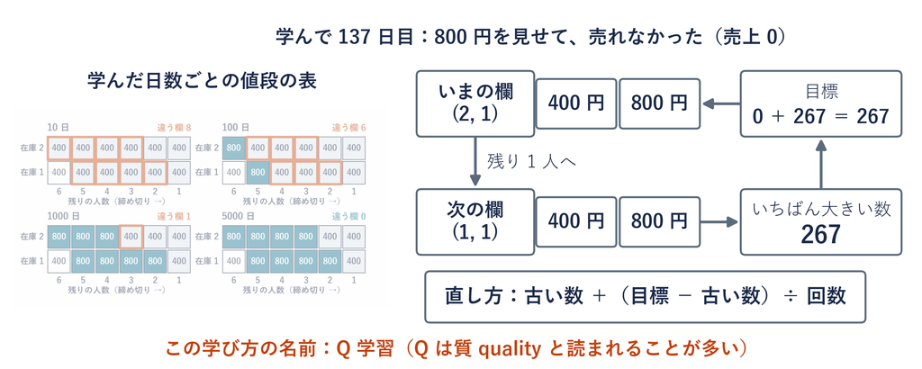

**売れなくても、次の客の分を足す**